# Case 4intelligence

## Parte C

**1. Importe a base “rendimento_efetivo_real.csv”.**

```r
rendimento <- read_csv2("data/rendimento_efetivo_real.csv")
```

```
## i Using "','" as decimal and "'.'" as grouping mark. Use `read_delim()` for more control.
```

```
## * `` -> ...3
```

**2. Renomeie as colunas para que tenhamos ”data”e ”renda”.**

```r
colnames(rendimento) <- c("data", "renda", "NA")

rendimento <- rendimento %>%
  select(data, renda)
```

```r
rendimento <- rendimento %>%
  mutate(data = parse_date_time(data, orders = "Ym"))
```

**4. Junte com a base anterior já organizada.**

```r
pmc_rend <- pmc %>%
  full_join(rendimento, by = "data") %>%
  select(data:br, renda) %>%
  filter(!is.na(renda))
```

**5. Gere uma visualização com as duas variáveis de interesse (note que é apenas para Brasil).**

Queremos gerar duas visualizações; scatterplot com distribuição marginal e side by side plots. Não colocaremos ambas as séries no mesmo plot pois suas escalas são diferentes.

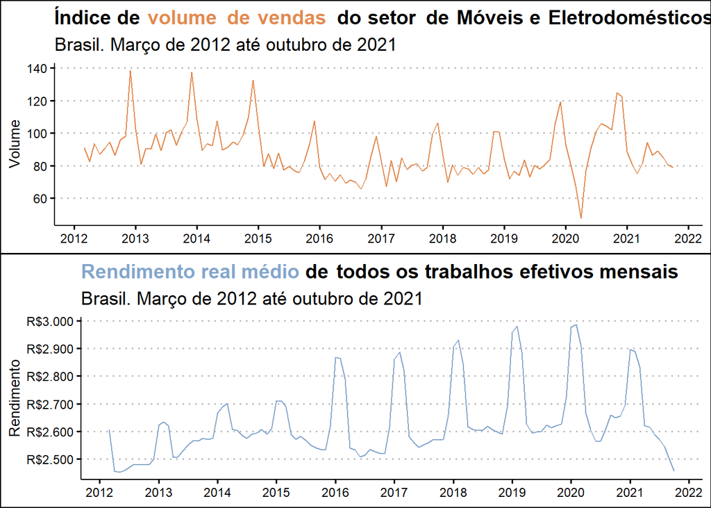

```r
p_rendimento <- pmc_rend %>%
  filter(setor == "Móveis e eletrodomésticos") %>%
  ggplot(aes(data))+
  geom_line(aes(y=renda), color = "#84a6cc")+
  scale_y_continuous(labels = scales::dollar_format(prefix = "R$",
                                                    big.mark = ".",
                                                    decimal.mark = ","),
                     breaks = seq(from = 2400, to = 3000, by = 100))+
  scale_x_datetime(date_labels = "%Y",
                   date_breaks = "1 year") +
  labs(x = NULL,
       y = "Rendimento",
       title = "**<span style='color:#84a6cc;'>Rendimento real médio</span> de todos os trabalhos efetivos mensais**",
       subtitle = "Brasil. Março de 2012 até outubro de 2021")+
  ggthemes::theme_clean()+
  theme(
    plot.title = element_markdown(lineheight = 1.1),
    legend.text = element_markdown(size = 11)
  )

p_volume <- pmc_rend %>%
  filter(setor == "Móveis e eletrodomésticos") %>%
  ggplot(aes(data))+
  geom_line(aes(y=br), color = "#e28a50")+
  scale_x_datetime(date_labels = "%Y",
                   date_breaks = "1 year") +
  labs(x = NULL,
       y = "Volume",
       title = "**Índice de <span style='color:#e28a50;'>volume de vendas</span> do setor de Móveis e Eletrodomésticos**",
       subtitle = "Brasil. Março de 2012 até outubro de 2021")+
  ggthemes::theme_clean()+
  theme(
    plot.title = element_markdown(lineheight = 1.1)
  )

p_grid <- gridExtra::grid.arrange(p_volume,p_rendimento,  heights = c(1,1), widths = c(1), nrow = 2, newpage = FALSE)
```

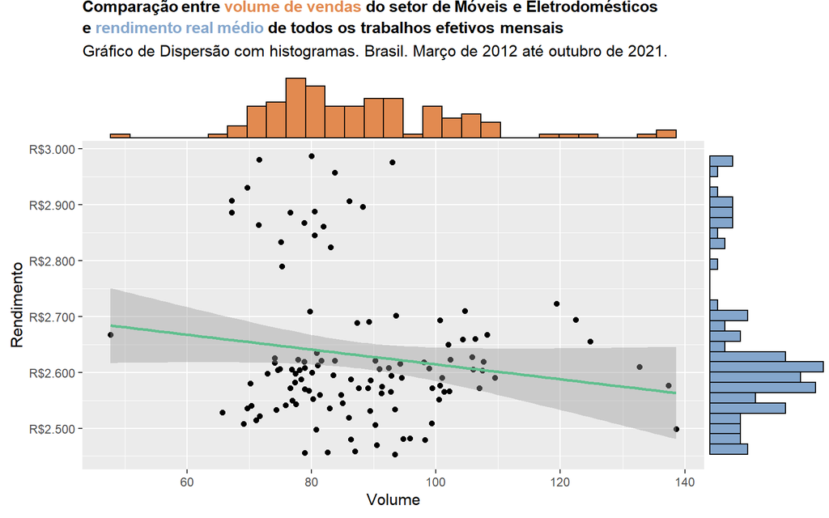

```r
ggsave("graphics/graficos_series_rendimento_volume.png", plot = p_grid, dpi = 300, width = 16, height = 12)

p <- pmc_rend %>%
  filter(setor == "Móveis e eletrodomésticos") %>%
  ggplot(aes(br, renda))+
  geom_point()+
  geom_smooth(method = "lm", color = "#60bf8e", formula = y ~ x)+
  scale_y_continuous(labels = scales::dollar_format(prefix = "R$",
                                                    big.mark = ".",
                                                    decimal.mark = ","),
                     breaks = seq(from = 2400, to = 3000, by = 100))+
  labs(x = "Volume",
       y = "Rendimento",
       title = "**<span style='font-size:11pt'>Comparação entre <span style='color:#e28a50;'>volume de vendas</span> do setor de Móveis e Eletrodomésticos  \ne <span style='color:#84a6cc;'>rendimento real médio</span> de todos os trabalhos efetivos mensais</span>**",
       subtitle = "Gráfico de Dispersão com histogramas. Brasil. Março de 2012 até outubro de 2021.")+
  theme(
    plot.title = element_markdown(lineheight = 1.1)
  )

p_marg <- ggMarginal(p, type = "histogram", xparams = list(fill = "#e28a50"),
           yparams = list(fill = "#84a6cc"))

ggsave("graphics/grafico_rendimento_volume_scatter.png", plot = p_marg, dpi = 200, width = 8, height = 5)
```

**6. Crie um modelo estatístico que estime a relação entre volume de vendas de móveis e eletrodomésticos com o rendimento real médio efetivo**

Dado que os dados são duas séries temporais, é necessário estimar um modelo de séries temporais multivariado. Podemos fazer um modelo tipo VAR ou tipo VECM, a depender do resultado do teste de cointegração, com a metodologia de Johansen. Além disso, vamos fazer o teste da raiz unitária, ADF (Augmented Dickley-Fuller) para saber se as séries são não-estacionárias ou estacionárias.

```r
# Criando as séries

pmc_wide <- pmc_rend %>%
  pivot_wider(names_from = setor,
              values_from = br)


serie_renda <- ts(pmc_wide$renda, start = c(2012, 03), frequency = 12)
serie_vol <- ts(pmc_wide$`Móveis e eletrodomésticos`, start = c(2012, 03), frequency = 12)

# Teste de raiz unitária

summary(ur.df(serie_renda))
```

```
##
## ###############################################
## # Augmented Dickey-Fuller Test Unit Root Test #
## ###############################################
##
## Test regression none
##
##
## Call:
## lm(formula = z.diff ~ z.lag.1 - 1 + z.diff.lag)
##
## Residuals:
##      Min       1Q   Median       3Q      Max
## -226.470  -19.924    1.952   22.314  230.944
##
## Coefficients:
##              Estimate Std. Error t value Pr(>|t|)
## z.lag.1    -0.0006291  0.0029525  -0.213 0.831650
## z.diff.lag  0.3373816  0.0877861   3.843 0.000202 ***
## ---
## Signif. codes:  0 '***' 0.001 '**' 0.01 '*' 0.05 '.' 0.1 ' ' 1
##
## Residual standard error: 83.07 on 112 degrees of freedom
## Multiple R-squared:  0.1168, Adjusted R-squared:  0.101
## F-statistic: 7.403 on 2 and 112 DF,  p-value: 0.0009559
##
##
## Value of test-statistic is: -0.2131
##
## Critical values for test statistics:
##       1pct  5pct 10pct
## tau1 -2.58 -1.95 -1.62
```

```r
summary(ur.df(serie_vol))
```

```
##
## ###############################################
## # Augmented Dickey-Fuller Test Unit Root Test #
## ###############################################
##
## Test regression none
##
##
## Call:
## lm(formula = z.diff ~ z.lag.1 - 1 + z.diff.lag)
##
## Residuals:
##     Min      1Q  Median      3Q     Max
## -33.114  -5.871   2.328   8.734  41.628
##
## Coefficients:
##            Estimate Std. Error t value Pr(>|t|)
## z.lag.1    -0.01091    0.01414  -0.772    0.442
## z.diff.lag -0.06523    0.09408  -0.693    0.490
##
## Residual standard error: 13.46 on 112 degrees of freedom
## Multiple R-squared:  0.01021,    Adjusted R-squared:  -0.007468
## F-statistic: 0.5775 on 2 and 112 DF,  p-value: 0.563
##
##
## Value of test-statistic is: -0.7716
##
## Critical values for test statistics:
##       1pct  5pct 10pct
## tau1 -2.58 -1.95 -1.62
```

```r
serie_renda_vol_diff <- cbind(diff(serie_renda, 1), diff(serie_vol, 1))
serie_renda_vol <- cbind(serie_renda, serie_vol)
```

Ambas as séries não rejeitaram a hipótese nula, de raiz unitária, pois os valores das estatísticas do teste são maiores que os valores de referência, logo são séries não estacionárias. Nosso modelo precisa ser I(1) para ambas séries.

Agora, descobrir a quantidade ótima de lags a serem usados

```r
VARselect(serie_renda_vol_diff, lag.max = 6)$selection
```

```
## AIC(n)  HQ(n)  SC(n) FPE(n)
##      6      3      3      6
```

Vamos testar a cointegração, estimar o modelo VECM e testá-lo para saber se é válido.

```r
jotest1 <- ca.jo(serie_renda_vol, type = "eigen", spec = "longrun", K = 4)
summary(jotest1)
```

```
##
## ######################
## # Johansen-Procedure #
## ######################
##
## Test type: maximal eigenvalue statistic (lambda max) , with linear trend
##
## Eigenvalues (lambda):
## [1] 0.15364830 0.04498908
##
## Values of teststatistic and critical values of test:
##
##           test 10pct  5pct  1pct
## r <= 1 |  5.16  6.50  8.18 11.65
## r = 0  | 18.68 12.91 14.90 19.19
##
## Eigenvectors, normalised to first column:
## (These are the cointegration relations)
##
##                serie_renda.l4 serie_vol.l4
## serie_renda.l4       1.000000      1.00000
## serie_vol.l4         6.970768    -10.31784
##
## Weights W:
## (This is the loading matrix)
##
##               serie_renda.l4 serie_vol.l4
## serie_renda.d    -0.01254059 -0.083093242
## serie_vol.d      -0.04331669  0.002483291
```

O teste sugere que rejeitemos a hipótese nula de não integração a 5%. Vamos construir então o modelo VECM

```r
modelo_vecm <- VECM(serie_renda_vol, 4, r = 1, estim = "ML")
summary(modelo_vecm)
```

```
## #############
## ###Model VECM
## #############
## Full sample size: 116    End sample size: 111
## Number of variables: 2   Number of estimated slope parameters 20
## AIC 1431.455     BIC 1488.355    SSR 294851.5
## Cointegrating vector (estimated by ML):
##    serie_renda serie_vol
## r1           1  3.633351
##
##
##                      ECT                Intercept
## Equation serie_renda -0.1367(0.0636)*   404.3968(187.9274)*
## Equation serie_vol   -0.0525(0.0132)*** 155.2246(39.1737)***
##                      serie_renda -1      serie_vol -1        serie_renda -2
## Equation serie_renda 0.2976(0.1068)**    3.2866(0.4456)***   0.3003(0.0852)***
## Equation serie_vol   -0.0212(0.0223)     -0.1070(0.0929)     0.0560(0.0178)**
##                      serie_vol -2       serie_renda -3      serie_vol -3
## Equation serie_renda 2.8809(0.5007)***  -0.2613(0.0832)**   2.5255(0.5639)***
## Equation serie_vol   -0.2472(0.1044)*   -0.0199(0.0173)     -0.1313(0.1175)
##                      serie_renda -4     serie_vol -4
## Equation serie_renda 0.2613(0.0831)**   -0.5779(0.5407)
## Equation serie_vol   0.0144(0.0173)     -0.0973(0.1127)
```

```r
# Transformar VECM em VAR para fazer o teste de autocorrelação

modelo_vecvar <- vec2var(jotest1, r = 1)
serial.test(modelo_vecvar)
```

```
##
##  Portmanteau Test (asymptotic)
##
## data:  Residuals of VAR object modelo_vecvar
## Chi-squared = 149.7, df = 50, p-value = 7.011e-12
```

Pelo teste, o modelo possui autocorrelação, logo não está bem especificado. Vamos fazer um modelo VAR para testar se o modelo seria melhor, pois a 1%, não há cointegração, pelo teste anterior.

```r
modelo_var <- VAR(serie_renda_vol_diff, p = 4)
summary(modelo_var)
```

```
##
## VAR Estimation Results:
## =========================
## Endogenous variables: diff.serie_renda..1., diff.serie_vol..1.
## Deterministic variables: const
## Sample size: 111
## Log Likelihood: -1021.585
## Roots of the characteristic polynomial:
## 0.8018 0.8018 0.7591 0.7591 0.6418 0.6418 0.5631 0.3736
## Call:
## VAR(y = serie_renda_vol_diff, p = 4)
##
##
## Estimation results for equation diff.serie_renda..1.:
## =====================================================
## diff.serie_renda..1. = diff.serie_renda..1..l1 + diff.serie_vol..1..l1 + diff.serie_renda..1..l2 + diff.serie_vol..1..l2 + diff.serie_renda..1..l3 + diff.serie_vol..1..l3 + diff.serie_renda..1..l4 + diff.serie_vol..1..l4 + const
##
##                         Estimate Std. Error t value Pr(>|t|)
## diff.serie_renda..1..l1  0.18799    0.09546   1.969  0.05163 .
## diff.serie_vol..1..l1    3.18210    0.45075   7.060 2.08e-10 ***
## diff.serie_renda..1..l2  0.24558    0.08274   2.968  0.00374 **
## diff.serie_vol..1..l2    2.87576    0.50957   5.644 1.50e-07 ***
## diff.serie_renda..1..l3 -0.32621    0.07890  -4.134 7.32e-05 ***
## diff.serie_vol..1..l3    2.42831    0.57196   4.246 4.82e-05 ***
## diff.serie_renda..1..l4  0.19023    0.07758   2.452  0.01591 *
## diff.serie_vol..1..l4   -0.64919    0.54922  -1.182  0.23994
## const                    0.20222    5.10988   0.040  0.96851
## ---
## Signif. codes:  0 '***' 0.001 '**' 0.01 '*' 0.05 '.' 0.1 ' ' 1
##
##
## Residual standard error: 53.83 on 102 degrees of freedom
## Multiple R-Squared: 0.6622,  Adjusted R-squared: 0.6357
## F-statistic: 24.99 on 8 and 102 DF,  p-value: < 2.2e-16
##
##
## Estimation results for equation diff.serie_vol..1.:
## ===================================================
## diff.serie_vol..1. = diff.serie_renda..1..l1 + diff.serie_vol..1..l1 + diff.serie_renda..1..l2 + diff.serie_vol..1..l2 + diff.serie_renda..1..l3 + diff.serie_vol..1..l3 + diff.serie_renda..1..l4 + diff.serie_vol..1..l4 + const
##
```

[output cut: 14 more lines]

```
## Residual standard error: 11.8 on 102 degrees of freedom
## Multiple R-Squared: 0.3018,  Adjusted R-squared: 0.247
## F-statistic: 5.511 on 8 and 102 DF,  p-value: 8.623e-06
##
##
##
## Covariance matrix of residuals:
##                      diff.serie_renda..1. diff.serie_vol..1.
## diff.serie_renda..1.              2897.30             -51.47
## diff.serie_vol..1.                 -51.47             139.12
##
## Correlation matrix of residuals:
##                      diff.serie_renda..1. diff.serie_vol..1.
## diff.serie_renda..1.              1.00000           -0.08107
## diff.serie_vol..1.               -0.08107            1.00000
```

```r
coef(modelo_var)
```

```
## $diff.serie_renda..1.
##                           Estimate Std. Error     t value     Pr(>|t|)
## diff.serie_renda..1..l1  0.1879865 0.09545781  1.96931445 5.162948e-02
## diff.serie_vol..1..l1    3.1820993 0.45074832  7.05959203 2.082305e-10
## diff.serie_renda..1..l2  0.2455805 0.08274352  2.96797199 3.735675e-03
## diff.serie_vol..1..l2    2.8757587 0.50956965  5.64350467 1.503342e-07
## diff.serie_renda..1..l3 -0.3262074 0.07890386 -4.13423928 7.321598e-05
## diff.serie_vol..1..l3    2.4283073 0.57195820  4.24560273 4.818434e-05
## diff.serie_renda..1..l4  0.1902302 0.07758415  2.45192128 1.590826e-02
## diff.serie_vol..1..l4   -0.6491924 0.54921668 -1.18203336 2.399408e-01
## const                    0.2022202 5.10988415  0.03957432 9.685099e-01
##
## $diff.serie_vol..1.
##                            Estimate Std. Error     t value   Pr(>|t|)
## diff.serie_renda..1..l1 -0.06331640 0.02091779 -3.02691660 0.00312807
## diff.serie_vol..1..l1   -0.14709147 0.09877303 -1.48918655 0.13952379
## diff.serie_renda..1..l2  0.03493425 0.01813169  1.92669570 0.05680051
## diff.serie_vol..1..l2   -0.24915223 0.11166262 -2.23129479 0.02785031
## diff.serie_renda..1..l3 -0.04487916 0.01729030 -2.59562625 0.01083381
## diff.serie_vol..1..l3   -0.16869541 0.12533390 -1.34596787 0.18129684
## diff.serie_renda..1..l4 -0.01291423 0.01700111 -0.75961111 0.44923912
## diff.serie_vol..1..l4   -0.12466254 0.12035053 -1.03582876 0.30273154
## const                   -0.08930132 1.11973519 -0.07975218 0.93659062
```

```r
serial.test(modelo_var, lags.pt = 5)
```

```
##
##  Portmanteau Test (asymptotic)
##
## data:  Residuals of VAR object modelo_var
## Chi-squared = 14.52, df = 4, p-value = 0.005808
```

O teste de diagnóstico também indica autocorrelação, embora o p-valor seja maior do que no teste do modelo VECM.